# BioStat_HW_17

## Exercises for Applied Biostatistics I - HS 2018

### 17.

The data set bone-fracture contains 50 samples of the following four variables:

- conc: concentration of the degradation product of a drug. All patients are taking the same dosage of the drug.
- dif: difference between needed and available screw length. The needed screw length is determined based on X-ray images of the bone fracture. However, screws are only available in steps of 5 mm. The column dif lists the difference of the needed screw length to the nearest available length.
- no.cells: number of cells counted in a proliferation assay. In this assay, the number of living cells in a petri dish are counted at a specific time.
- hit: success (hit = 1) or failure (hit = 0) of a manual prediction whether a bone is fractured or not. The physician E. Bruch claims that he is able to determine with his own hands whether a bone is fractured or not, without looking at an X-ray image.

You find the data set under *bone-fracture.csv* on ILIAS and can read it in as follows:

```r
fracture <- read.table("bone-fracture.csv", sep = ";", header = TRUE)
summary(fracture)
```

```
##       conc            dif              no.cells          hit
##  Min.   :2.619   Min.   :-2.39276   Min.   :146.0   Min.   :0.00
##  1st Qu.:3.186   1st Qu.:-1.01507   1st Qu.:167.0   1st Qu.:0.00
##  Median :3.407   Median : 0.31729   Median :174.0   Median :1.00
##  Mean   :3.411   Mean   : 0.08855   Mean   :174.2   Mean   :0.68
##  3rd Qu.:3.677   3rd Qu.: 1.29224   3rd Qu.:181.8   3rd Qu.:1.00
##  Max.   :4.100   Max.   : 2.40708   Max.   :200.0   Max.   :1.00
```

```r
str(fracture)
```

```
## 'data.frame':    50 obs. of  4 variables:
##  $ conc    : num  2.83 4.09 2.88 2.84 3.22 ...
##  $ dif     : num  1.695 -0.139 -1.011 -0.186 -0.85 ...
##  $ no.cells: int  166 188 176 172 190 173 167 175 181 184 ...
##  $ hit     : int  0 1 1 1 1 0 1 0 1 0 ...
```

Find an appropriate distribution for each of the four random variables and estimate its parameters. If possible, indicate an approximate 95% confidence interval for each parameter. Visualize the distribution of the data and the distribution of your fitted model.

## Creating a general plot function

```r
library("car")
```

```r
fdata <- fracture$conc
desc <- "concentration"

compDists <- function(fdata, desc) {
#  def.par=par(no.readonly = T)
#  layout.show(layout(matrix(c(1,1,2,3), nrow=2, ncol=2, byrow = TRUE)))

  dmin <- floor(min(fdata))
  dmax <- ceiling(max(fdata))
  size <- length(fdata)
  size <- length(fdata)
  hist(fdata, freq = F, breaks = 20, xlab = desc, xlim = c(dmin, dmax), main = paste("Histogram of ", desc))
  mu <- mean(fdata)
  abline(v = mu, lwd = 2, col = "blue")
  sd <- sd(fdata)
  max <- max(fdata)
  sem <- sd(fdata)/sqrt(size)
  a <- 1 - .05/2
  fi <- qnorm(a,0)
  lines(c(mu - sem, mu + sem), c(0,0), lwd = 2, col = "red")
  text(mu + sem, 0,"SEM")

  xseq=seq(dmin,dmax, (dmax-dmin)/100)
  lines(xseq, dnorm(xseq, mean=mean(fdata), sd=sd(fdata)), lwd = 2, col = "steelblue")
  lines(xseq, dunif(xseq, min = dmin, max = dmax), lwd = 2, col = "green")
  #lines(xseq, dpois(xseq, lambda = mean(fdata)), lwd = 2, col = "red")

  # another test of normality using the Shapiro-Wilk-Test
  shp.test <- shapiro.test(fdata)
  spw <- round(shp.test$statistic,3)
  spval <- round(shp.test$p.value,3)
  # W close to 1 and p-value < 0.05 means the data is not normaly distributed

  qqPlot(fdata, dist = "norm", main = paste(desc, " vs Normal distribution"), xlab = paste("Theor. quantiles (norm) shapiro W:", spw, " , p-val:", spval), ylab = "Empirical quantiles", envelope=.975)
  qqPlot(fdata, dist = "unif", main = paste(desc, " vs Uniform distribution"), xlab = "Theor. quantiles (unif)", ylab = "Empirical quantiles", envelope=.975)
#  qqPlot(fdata, dist = "pois", main = " vs Poisson distribution", xlab = "Theor. quantiles (poisson-distribution)", ylab = "Empirical quantiles", lambda = mean(fdata))
#  qqPlot(fdata, dist = "exp", main = " vs Exponential distribution", xlab = "Theor. quantiles (exp-distribution)", ylab = "Empirical quantiles")
#  qqPlot(fdata, dist = "t", main = " vs Student's T distribution", xlab = "Theor. quantiles (t-distribution)", ylab = "Empirical quantiles", df = 49)

#  par(def.par)
}
```

Ploting comparation distributions for the “concentration”

```r
summary(fracture$conc)
```

```
##    Min. 1st Qu.  Median    Mean 3rd Qu.    Max.
##   2.619   3.186   3.407   3.411   3.677   4.100
```

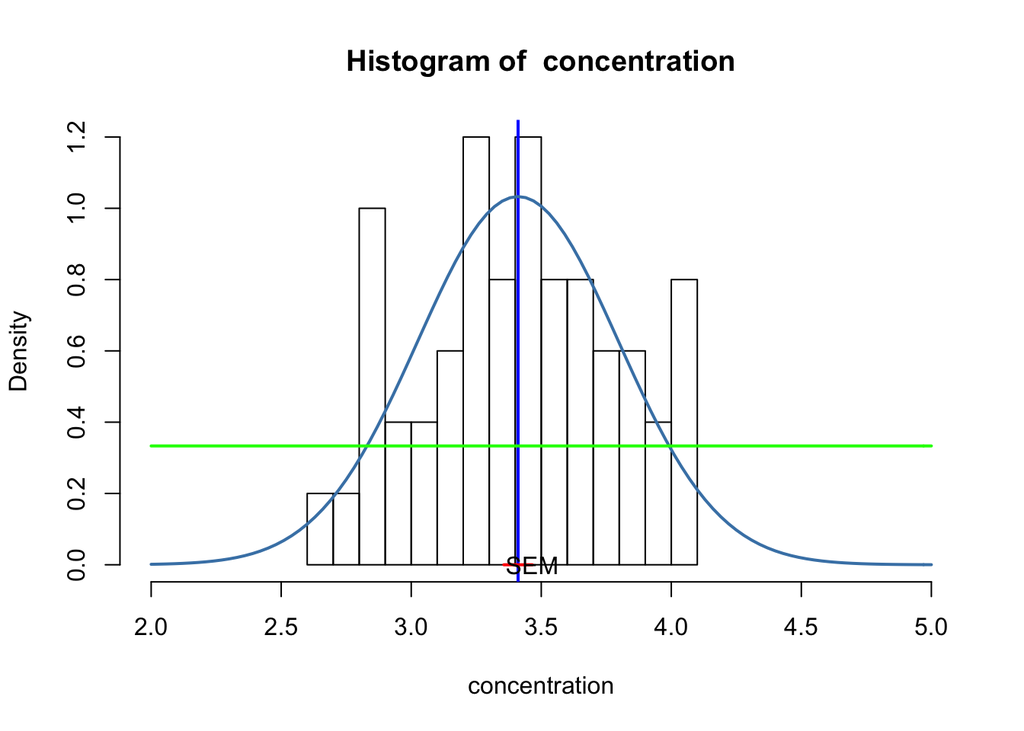

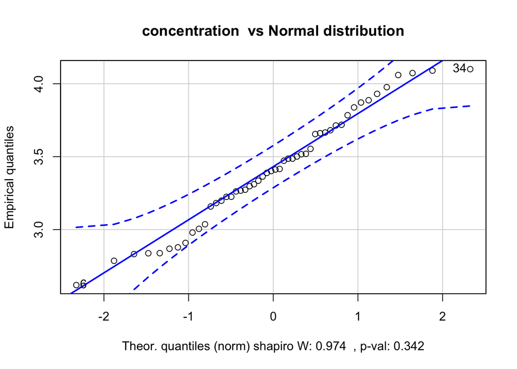

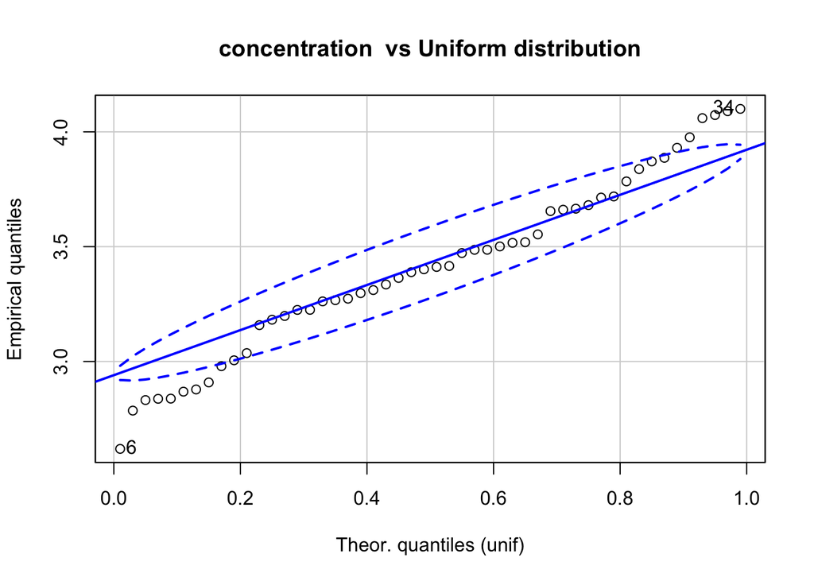

```
## [1]  6 34
```

```r
compDists(fracture$conc, "concentration")
```

Ploting comparation distributions for the “difference”

```r
summary(fracture$dif)
```

```
##     Min.  1st Qu.   Median     Mean  3rd Qu.     Max.
## -2.39276 -1.01507  0.31729  0.08855  1.29224  2.40708
```

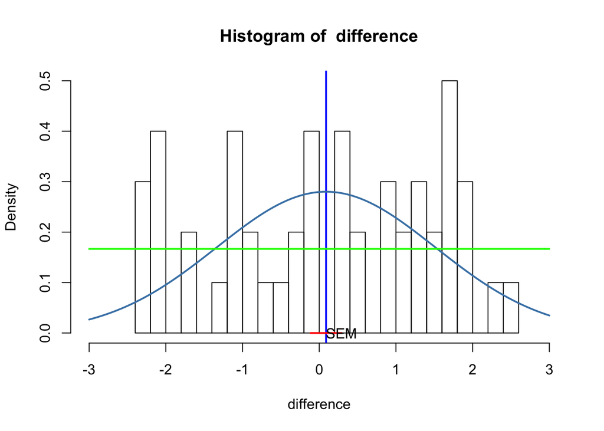

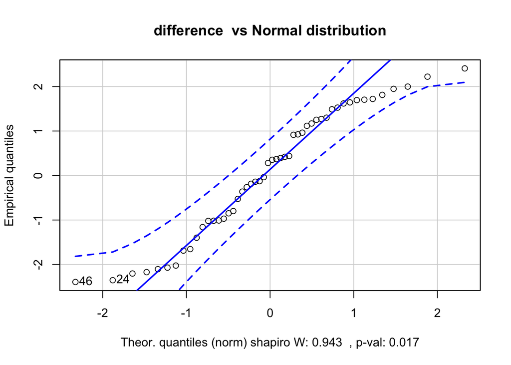

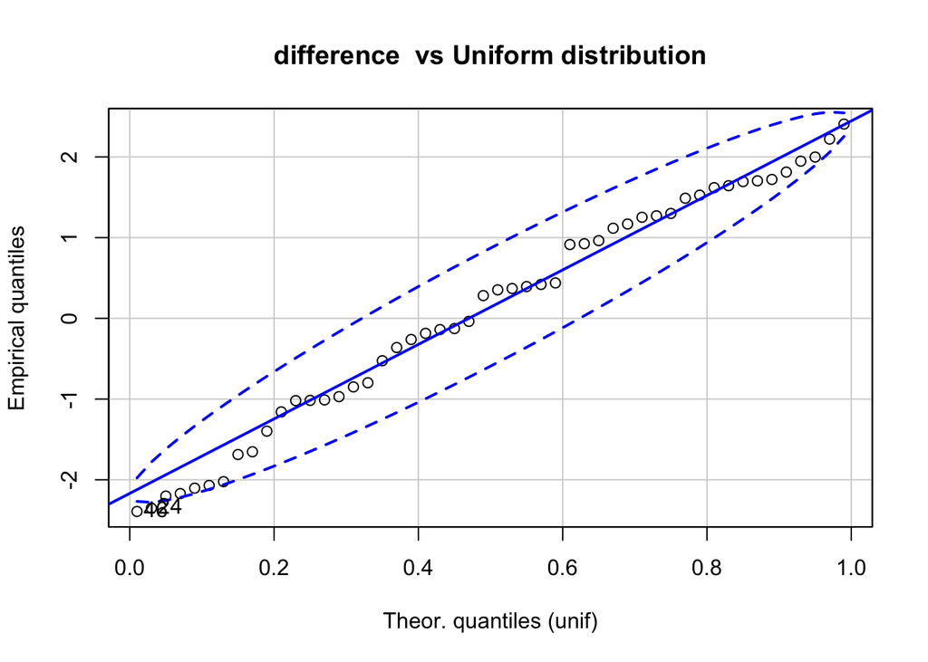

```
## [1] 46 24
```

```r
compDists(fracture$dif, "difference")
```

Ploting comparation distributions for the “number of cells”

```r
summary(fracture$no.cells)
```

```
##    Min. 1st Qu.  Median    Mean 3rd Qu.    Max.
##   146.0   167.0   174.0   174.2   181.8   200.0
```

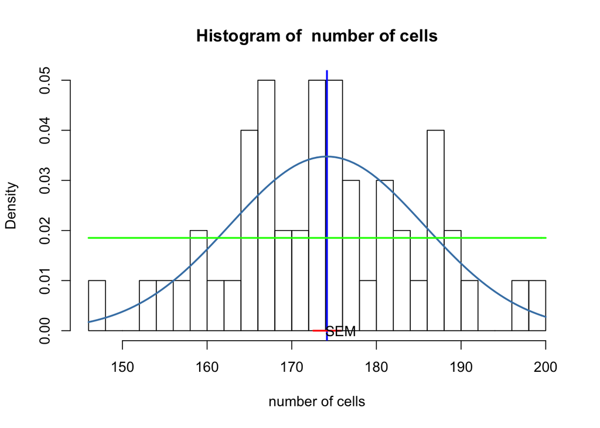

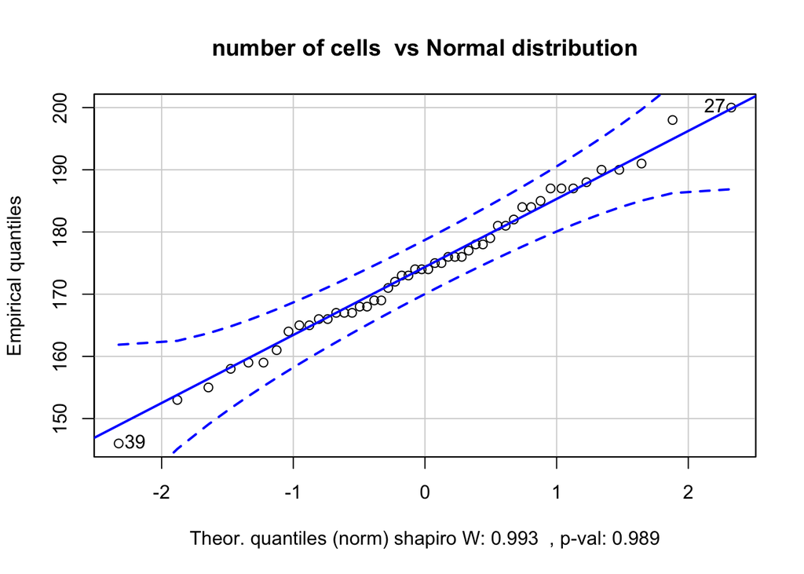

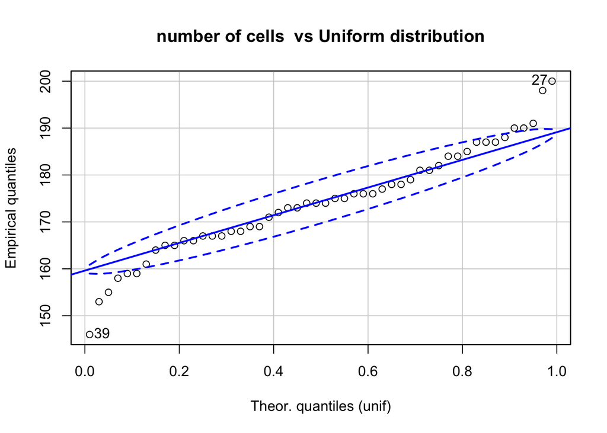

```
## [1] 39 27
```

```r
compDists(fracture$no.cells, "number of cells")
```

```r
fdata <- fracture$hit
summary(fdata)
```

```
##    Min. 1st Qu.  Median    Mean 3rd Qu.    Max.
##    0.00    0.00    1.00    0.68    1.00    1.00
```

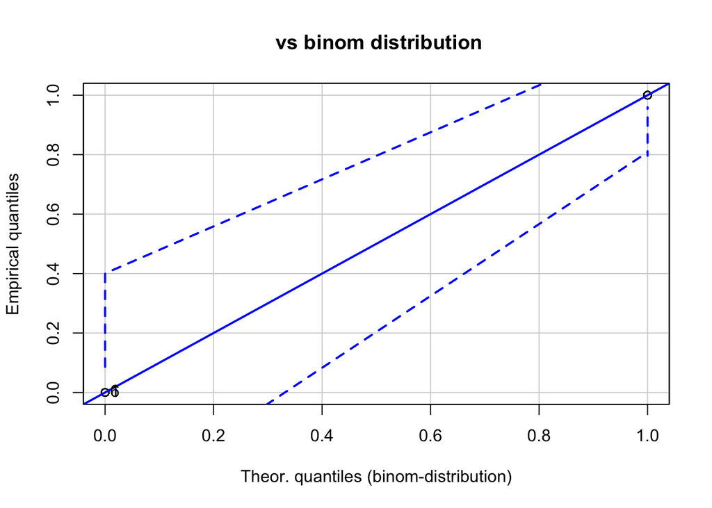

```
## [1] 1 6
```

```r
qqPlot(fdata, dist = "binom", main = " vs binom distribution", xlab = "Theor. quantiles (binom-distribution)", ylab = "Empirical quantiles", size=1, prob=mean(fdata))
```

```r
size <- length(fdata)
success <- length(fdata[fdata==1])
(1 - pbinom(success, size=size, prob = .5))
```

```
## [1] 0.003300224
```

```r
binom.test(x=success,n=size)
```

```
##
##  Exact binomial test
##
## data:  success and size
## number of successes = 34, number of trials = 50, p-value = 0.01535
## alternative hypothesis: true probability of success is not equal to 0.5
## 95 percent confidence interval:
##  0.5330062 0.8047958
## sample estimates:
## probability of success
##                   0.68
```

```r
#var(fdata)
```